# Analysis_simulateddataset

Karim Barigou

2025-02-17

## Introduction

This document demonstrates the simulation of data presented in the course, along with tree-based modeling using the **rpart** package. The analysis includes: - Simulating the dataset. - Fitting tree models with different maximum depths. - Visualizing the tree models. - Pruning the tree iteratively to identify the optimal model based on cross-validation.

## Setup

We load the required libraries.

```r
# Set a seed for reproducibility
set.seed(123)

# Load necessary libraries
library(rpart)
library(rpart.plot)
```

## Data Simulation

We simulate a dataset with 1,000,000 observations. The dataset includes four covariates: Gender (male or female), Age (18 to 65), Split of the annual premium (yes or no), Sports car (yes or no). Then, we compute the expected claim frequency and simulate the number of claims.

```r
# Number of simulations
n <- 1000000

# Simulating the features
X1 <- sample(c("female", "male"), size = n, replace = TRUE, prob = c(0.5, 0.5))
X2 <- sample(18:65, size = n, replace = TRUE, prob = rep(1/48, 48))
X3 <- sample(c("yes", "no"), size = n, replace = TRUE, prob = c(0.5, 0.5))
X4 <- sample(c("yes", "no"), size = n, replace = TRUE, prob = c(0.5, 0.5))

# Compute expected claim frequency μ(x)
mu <- 0.1 *
  (1 + 0.1 * (X1 == "male")) *
  (1 + 0.4 * (X2 >= 18 & X2 < 30) + 0.2 * (X2 >= 30 & X2 < 45)) *
  (1 + 0.15 * (X4 == "yes"))

# Simulate response variable Y (number of claims) following a Poisson distribution
Y <- rpois(n, lambda = mu)

# Combine into a dataframe
data <- data.frame(Y, Gender = X1, Age = X2, Split = X3, Sport = X4)

# Display the first 10 rows of the data
head(data, 10)
```

```
##    Y Gender Age Split Sport
## 1  0   male  47    no   yes
## 2  0 female  30    no   yes
## 3  0   male  22   yes    no
## 4  0 female  52   yes   yes
## 5  0 female  47    no   yes
## 6  0   male  59   yes   yes
## 7  0 female  54   yes    no
## 8  0 female  33   yes   yes
## 9  0 female  38   yes   yes
## 10 0   male  60    no    no
```

## Fitting a Tree Model (Maximum Depth = 3)

Here we fit a tree-based model using **rpart** with a maximum tree depth of 3. The model is used to predict the number of claims based on the features. As we have seen in the course, this leads to a **underfitted** model as some important features are missing.

```r
# Fit the tree model with maximum depth = 3
tree <- rpart(
  Y ~ Gender + Age + Split + Sport,
  data = data,
  method = "poisson",
  control = rpart.control(minsplit = 50, cp = 0, maxdepth = 3)
)

# Display the tree structure
print(tree)
```

```
## n= 1000000
##
## node), split, n, deviance, yval
##       * denotes terminal node
##
##  1) root 1000000 557414.10 0.13156700
##    2) Age>=44.5 438231 223211.20 0.11284490
##      4) Sport=no 219442 106816.80 0.10468920
##        8) Gender=female 109809  51793.11 0.09961153 *
##        9) Gender=male 109633  54969.52 0.10977690 *
##      5) Sport=yes 218789 116135.00 0.12102560
##       10) Gender=female 108963  56164.47 0.11501270 *
##       11) Gender=male 109826  59905.66 0.12699210 *
##    3) Age< 44.5 561769 332096.80 0.14617200
##      6) Age>=29.5 312481 177117.20 0.13556330
##       12) Sport=no 156352  84774.38 0.12532650 *
##       13) Sport=yes 156129  92100.72 0.14581460 *
##      7) Age< 29.5 249288 154440.10 0.15946930
##       14) Sport=no 124318  73912.90 0.14791000 *
##       15) Sport=yes 124970  80319.21 0.17096660 *
```

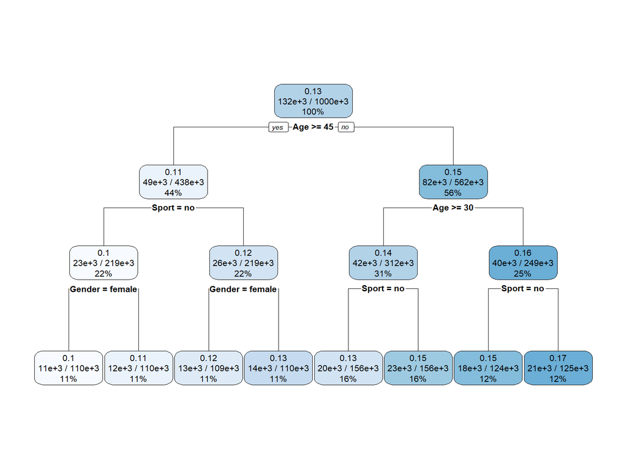

```r
# Plot the tree
rpart.plot(tree)
```

## Fitting a Full Tree Model (Maximum Depth = 4)

We then fit a full tree model with a maximum depth of 4. As we have seen in the course, this leads to an **overfitted** model given that some unnecessary branches appear now in the tree.

```r
# Fit the tree model with maximum depth = 4
fulltree <- rpart(
  Y ~ Gender + Age + Split + Sport,
  data = data,
  method = "poisson",
  control = rpart.control(cp = 0, maxdepth = 4)
)

# Display the tree structure
print(fulltree)
```

```
## n= 1000000
##
## node), split, n, deviance, yval
##       * denotes terminal node
##
##  1) root 1000000 557414.100 0.13156700
##    2) Age>=44.5 438231 223211.200 0.11284490
##      4) Sport=no 219442 106816.800 0.10468920
##        8) Gender=female 109809  51793.110 0.09961153
##         16) Age< 45.5 5283   2426.332 0.09450723 *
##         17) Age>=45.5 104526  49365.280 0.09987219 *
##        9) Gender=male 109633  54969.520 0.10977690
##         18) Age< 48.5 21052  10382.160 0.10650720 *
##         19) Age>=48.5 88581  44584.790 0.11055600 *
##      5) Sport=yes 218789 116135.000 0.12102560
##       10) Gender=female 108963  56164.470 0.11501270
##         20) Age< 59.5 77713  39704.780 0.11339340 *
##         21) Age>=59.5 31250  16453.540 0.11904300 *
##       11) Gender=male 109826  59905.660 0.12699210
##         22) Age>=64.5 5324   2763.800 0.11778830 *
##         23) Age< 64.5 104502  57138.030 0.12746200 *
##    3) Age< 44.5 561769 332096.800 0.14617200
##      6) Age>=29.5 312481 177117.200 0.13556330
##       12) Sport=no 156352  84774.380 0.12532650
##         24) Gender=female 77990  41221.050 0.11964470 *
##         25) Gender=male 78362  43513.220 0.13098190 *
##       13) Sport=yes 156129  92100.720 0.14581460
##         26) Gender=female 77757  44511.150 0.13809630 *
##         27) Gender=male 78372  47526.250 0.15347110 *
##      7) Age< 29.5 249288 154440.100 0.15946930
##       14) Sport=no 124318  73912.900 0.14791000
##         28) Gender=female 61994  35656.240 0.13957700 *
##         29) Gender=male 62324  38198.580 0.15619690 *
##       15) Sport=yes 124970  80319.210 0.17096660
##         30) Gender=female 62671  39534.270 0.16458570 *
##         31) Gender=male 62299  40755.020 0.17738090 *
```

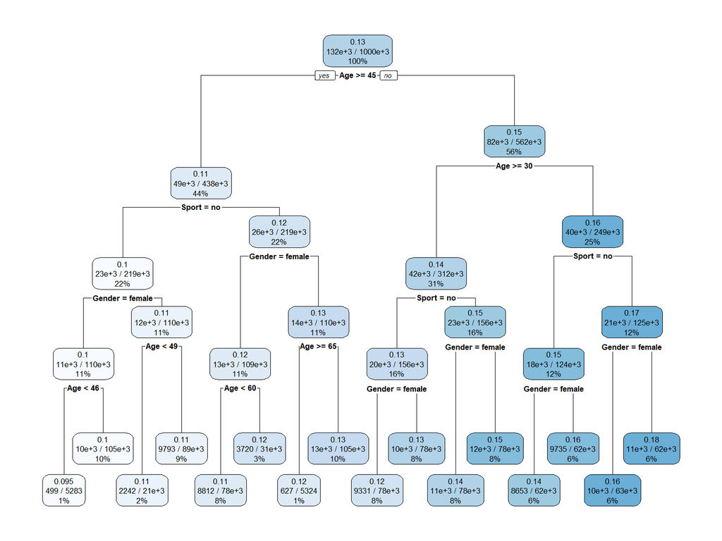

```r
# Plot the tree
rpart.plot(fulltree)
```

```r
# Print complexity parameters
printcp(fulltree)
```

```
##
## Rates regression tree:
## rpart(formula = Y ~ Gender + Age + Split + Sport, data = data,
##     method = "poisson", control = rpart.control(cp = 0, maxdepth = 4))
##
## Variables actually used in tree construction:
## [1] Age    Gender Sport
##
## Root node error: 557414/1000000 = 0.55741
##
## n= 1000000
##
##            CP nsplit rel error  xerror      xstd
## 1  3.7784e-03      0   1.00000 1.00000 0.0016282
## 2  9.6781e-04      1   0.99622 0.99623 0.0016233
## 3  4.6524e-04      2   0.99525 0.99527 0.0016224
## 4  4.3440e-04      3   0.99479 0.99497 0.0016222
## 5  3.7313e-04      4   0.99435 0.99444 0.0016215
## 6  1.1643e-04      5   0.99398 0.99401 0.0016209
## 7  1.1361e-04      6   0.99386 0.99400 0.0016211
## 8  1.0421e-04      7   0.99375 0.99394 0.0016211
## 9  9.7195e-05      8   0.99365 0.99384 0.0016209
## 10 7.1961e-05      9   0.99355 0.99361 0.0016204
## 11 5.3693e-05     10   0.99348 0.99356 0.0016204
## 12 1.1016e-05     11   0.99342 0.99348 0.0016204
## 13 6.8843e-06     12   0.99341 0.99350 0.0016204
## 14 4.6082e-06     13   0.99341 0.99352 0.0016205
## 15 2.7011e-06     14   0.99340 0.99352 0.0016205
## 16 0.0000e+00     15   0.99340 0.99352 0.0016205
```

## Tree Pruning

Based on the table of the complexity parameters, we know that we will reach the optimal tree (the tree which minimizes the 10-fold cross-validation error) by pruning the tree four times iteratively. To do so, we extract the complexity parameter (cp) table and perform sequential pruning steps.

```r
# Extract the complexity parameter (cp) table
cp_table <- fulltree$cptable

# Get the "before last" cp value and print it
before_last_cp <- cp_table[nrow(cp_table) - 1, "CP"]
print(before_last_cp)
```

```
## [1] 2.701102e-06
```

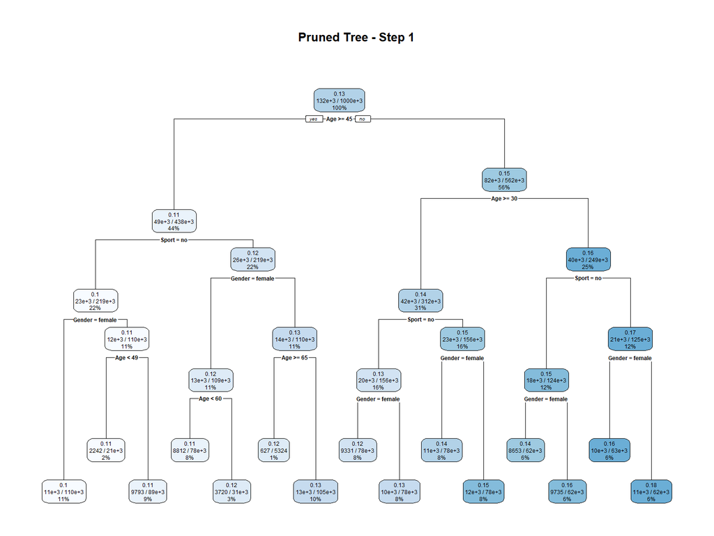

```r
# Prune the tree to the first CP value
tree_pruned_1 <- prune(fulltree, cp = cp_table[nrow(cp_table) - 1, "CP"])
rpart.plot(tree_pruned_1, main = "Pruned Tree - Step 1")
```

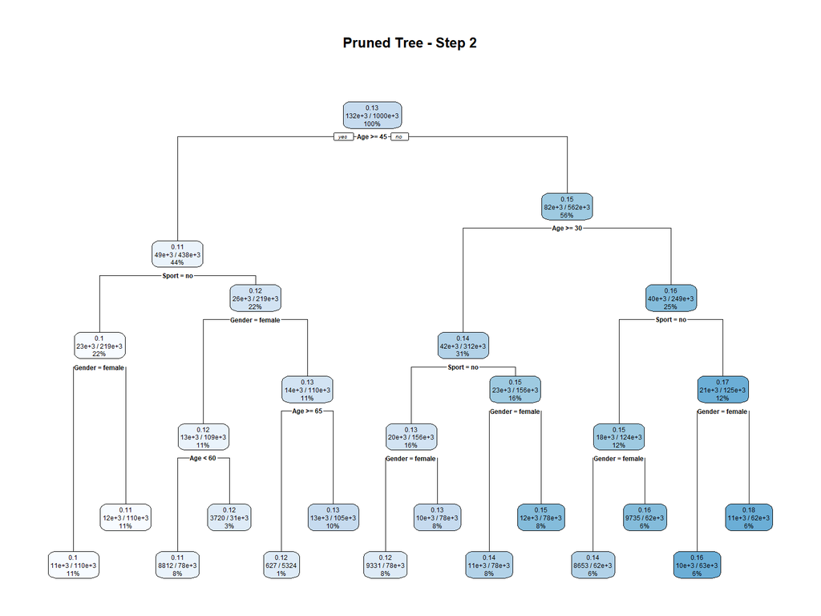

```r
# Prune the tree further using the next CP value
tree_pruned_2 <- prune(tree_pruned_1, cp = cp_table[nrow(cp_table) - 2, "CP"])
rpart.plot(tree_pruned_2, main = "Pruned Tree - Step 2")
```

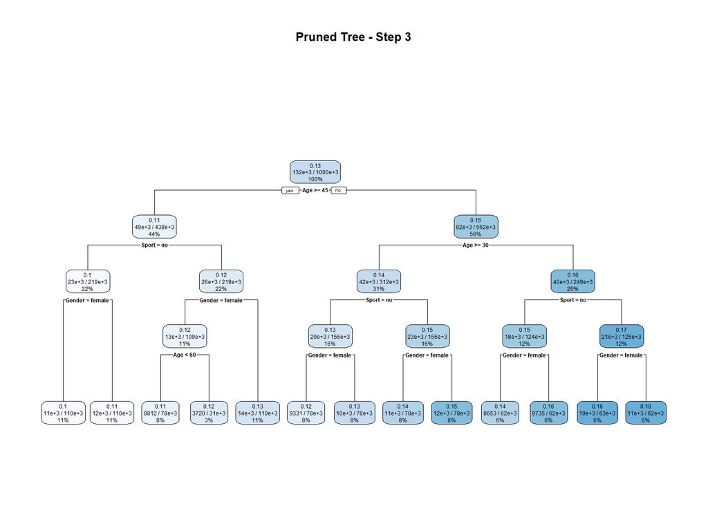

```r
# Continue pruning iteratively
tree_pruned_3 <- prune(tree_pruned_2, cp = cp_table[nrow(cp_table) - 3, "CP"])
rpart.plot(tree_pruned_3, main = "Pruned Tree - Step 3")
```

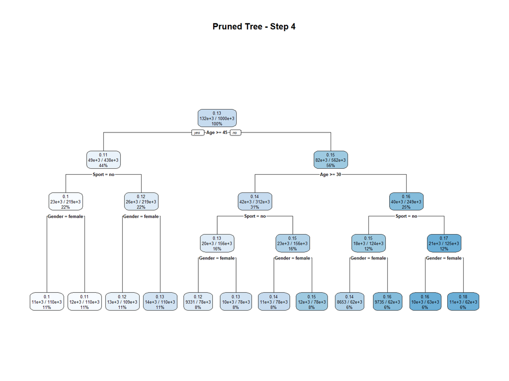

```r
tree_pruned_4 <- prune(tree_pruned_3, cp = cp_table[nrow(cp_table) - 4, "CP"])
rpart.plot(tree_pruned_4, main = "Pruned Tree - Step 4")
```

```r
# Print the CP table for the pruned tree, representing the optimal tree based on cross-validation
printcp(tree_pruned_4)
```

```
##
## Rates regression tree:
## rpart(formula = Y ~ Gender + Age + Split + Sport, data = data,
##     method = "poisson", control = rpart.control(cp = 0, maxdepth = 4))
##
## Variables actually used in tree construction:
## [1] Age    Gender Sport
##
## Root node error: 557414/1000000 = 0.55741
##
## n= 1000000
##
##            CP nsplit rel error  xerror      xstd
## 1  3.7784e-03      0   1.00000 1.00000 0.0016282
## 2  9.6781e-04      1   0.99622 0.99623 0.0016233
## 3  4.6524e-04      2   0.99525 0.99527 0.0016224
## 4  4.3440e-04      3   0.99479 0.99497 0.0016222
## 5  3.7313e-04      4   0.99435 0.99444 0.0016215
## 6  1.1643e-04      5   0.99398 0.99401 0.0016209
## 7  1.1361e-04      6   0.99386 0.99400 0.0016211
## 8  1.0421e-04      7   0.99375 0.99394 0.0016211
## 9  9.7195e-05      8   0.99365 0.99384 0.0016209
## 10 7.1961e-05      9   0.99355 0.99361 0.0016204
## 11 5.3693e-05     10   0.99348 0.99356 0.0016204
## 12 1.1016e-05     11   0.99342 0.99348 0.0016204
```